# The Role of Sanctions and Spillovers in Forest Conservation

Vieira, Dahis, and Assunção

APEC 8990

Paper Presentations

September 26, 2024

## Motivation

- Deforestation generates a range of negative externalities
- Limited evidence on the role of sanctions in preventing deforestation
  - These sanctions may have spatial spillover effects

### Research Question

> How do environmental sanctions and spillovers effect forest conservation in the Brazilian Amazon?

## Overview

- Context: Brazilian Amazon 2000-2019
  - Farms account for 53% of the Amazon’s deforestation
  - In the mid-2000s, the government implemented policies to reduce deforestation rates
- Methods:
  - Staggered difference-in-differences
- Findings:
  - Punished farmers decrease deforestation by 49%
  - Adjacent neighbors decrease by 21%

## Data

### Brazil 2000-2019

1. Farm-year panel data
   - Spatial data and tenure
2. Deforestation and Reforestation
   - Annual LULC 30mx30m, Mapbiomas
   - CO<sub>2</sub> emissions from aboveground biomass data, Global ForestWatch
3. Farm-year deforestation-related sanctions
   - Public administrative records, including fines, embargoes, and seizures

## Empirical Strategy

### Staggered DiD

For a given treatment type, an unconditional estimator for the average treatment effect of environmental sanctions for cohort $g$ at year $t \geq g$:

$$\widehat{ATT}^{type}(g, t) = \frac{\sum_{i} \Delta Y_{ig-1,t} 1\{G_{i}^{type} = g\}}{\sum_{i} 1 \{G_{i}^{type} = g\}} - \frac{\sum_{i} \Delta Y_{ig-1,t} C_{i}}{\sum_{i} C_{i}}$$

where

- $i \in {1, 2, ..., N}$ represents farms
- $t \in \{ 2000, 2001, ..., 2019 \}$ years
- $G_{i}^{type} = g \in \{2005, 2006, ..., 2019\}$ treatment cohorts of each type
- $C_{i} = 1$ the control group of never-treated farms
- $\Delta Y_{ig-1,t} = Y_{i,t} - Y_{i,g-1}$ the evolution of outcome $Y$ in a given year $t$ relative to the year before treatment $g - 1$

## Empirical Strategy

### Staggered DiD

$$\widehat{ATT}^{type}(g, t) = \frac{\sum_{i} \Delta Y_{ig-1,t} 1\{G_{i}^{type} = g\}}{\sum_{i} 1 \{G_{i}^{type} = g\}} - \frac{\sum_{i} \Delta Y_{ig-1,t} C_{i}}{\sum_{i} C_{i}}$$

- Equivalent to a two-period/two-group difference-in-differences estimator
  - Compares the average outcome evolution of the treated group in year $t$, post-treatment, relative to year $g - 1$, pre-treatment, with the average outcome evolution of the control group across the same periods
- Main results aggregated to show event studies
  - 5 years of pre- and post-treatment

## Results

### Sanction Effects on Deforestation and Reforestation

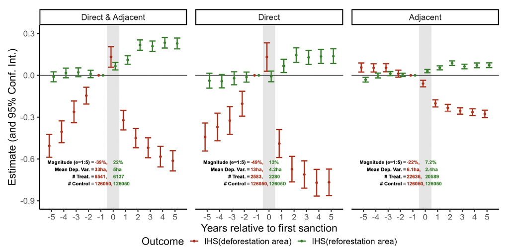

## Results

### Robustness to Parallel Trends Violation

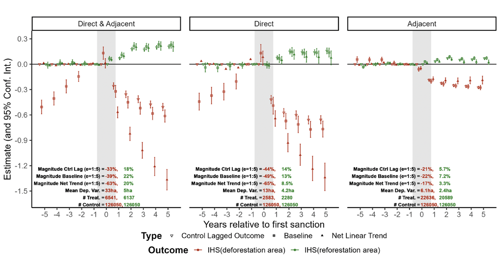

## Results

### Heterogeneity by Type of Sanction

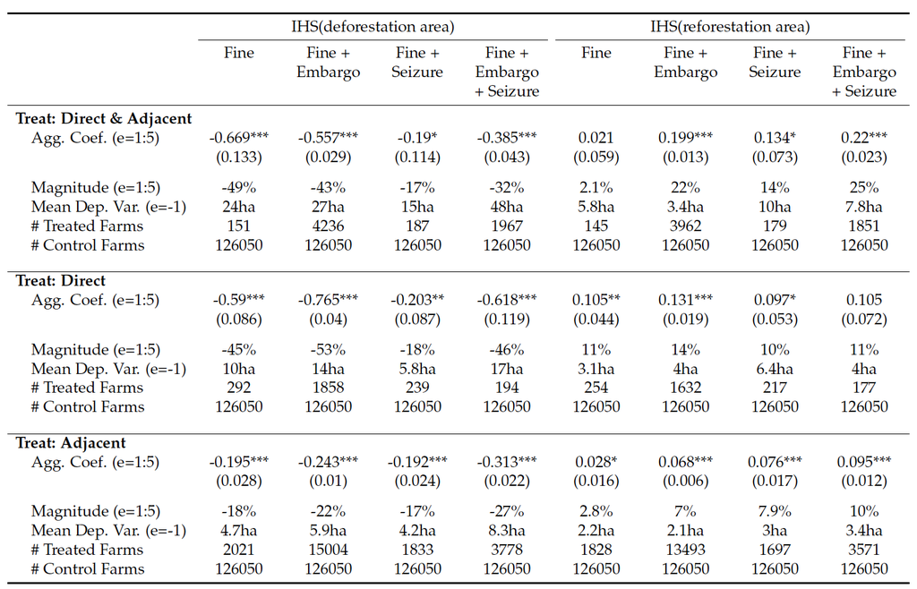

## Results

### Sanctions Effects Over Time

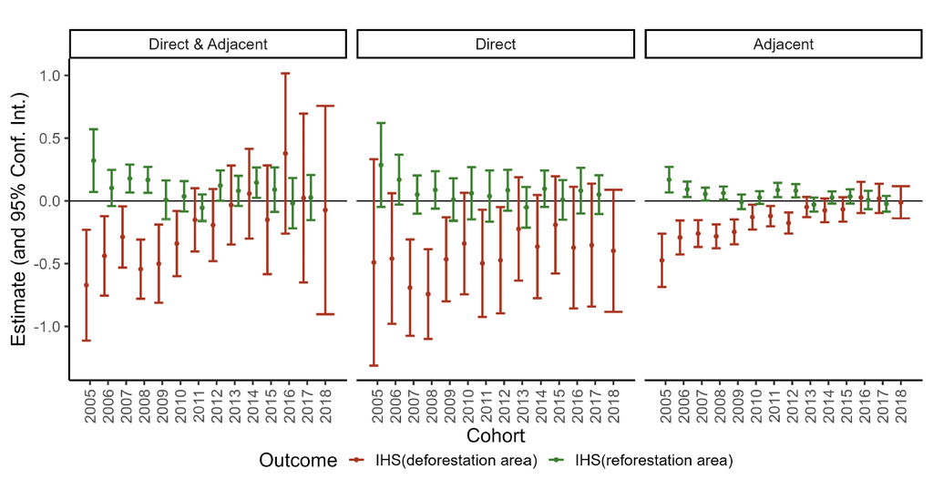

## Results

### Sanction Effects on Deforestation by Monitoring Degree

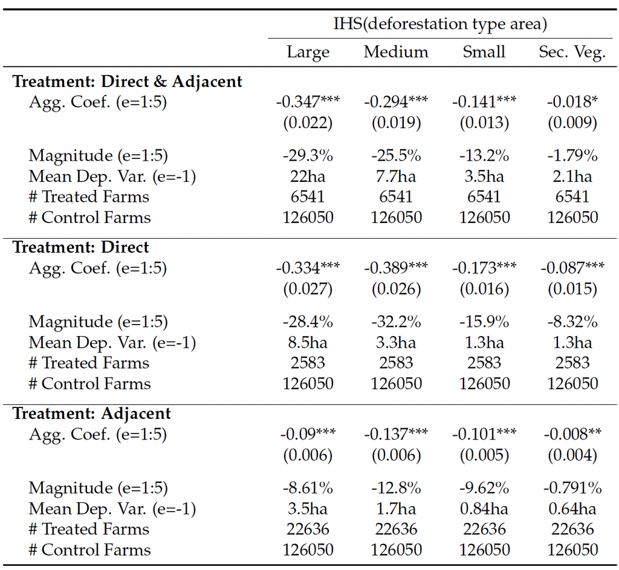

## Results

### Sanction Effects by Neighbor Distance

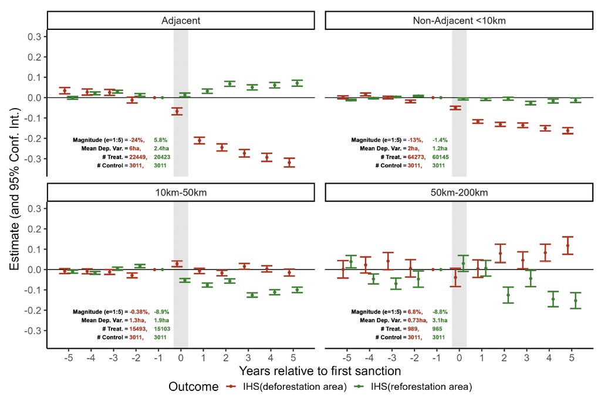

## Summary

- Sanctions generate persistent reductions in deforestation
  - Avoiding the emission of 1.599 billion tons of CO<sub>2</sub>
  - Despite relatively low rates of punishment
- Spillovers reduce deforestation among neighboring farmers
- No evidence of strategic displacement to farms further away from punishment